# Homework 5: RDD and Prediction I

STA 235H

Due on Nov. 4th, 11:59pm

# Note

- This document will serve as your Answer Key for Homework 5. Please check the rubric to understand how the assignment is graded.
- All automatically-graded questions will receive full credit if correct or 0 points if they are not correct. The only exception is with multiple answers were points are allocated proportionally.
- Inconsistencies between code and answers will be discounted (i.e. if an answer is correct, but the code used to get to that answer is not, that question will be discounted).
- R scripts and PDF files will also be checked for completeness. If they are not complete (i.e. do not contain the code/output requested), a discount will apply.
- After you receive your graded assignment, you will have one week to submit re-grading requests. Please compare your graded submission with this answer key and fill out the re-grading form with your specific request.

# Task 1 - Conceptual Questions

**1.1) Assess the following statement:** (2 points)

“A model with additional covariates is always better at prediction than a more restrictive model because it is able to capture all the different relations between the predictors and the outcomes”

Answer:

FALSE

**1.2) Which of the following statements is/are TRUE?**

1. In a Regression Discontinuity Design (RDD), we can’t estimate the effect of an intervention if everyone exactly at the cutoff (c=0) is treated in our sample.
2. In a difference-in-differences approach, we are comparing units in our treated group with units in our control group, after the intervention takes place.
3. In a Regression Discontinuity Design, we assume the running variable is continuous across the cutoff of eligibility.
4. In a random natural experiment, it shouldn’t be necessary to control by potential confounders.

Answer:

C and D

**1.3) A friend is trying to decide which model is better for prediction of a continuous outcome, and he shows you the following code output:**

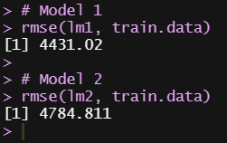

**What would you recommend?**

1. Model 1
2. Model 2
3. You need additional information

Answer:

C

**1.4) What would the advantage or disadvantage of fitting a more flexible model be in comparison to fitting a more restrictive one?**

1. A more flexible model has higher variance than a more restrictive one
2. A more flexible model has lower variance than a restrictive one
3. A more flexible model has lower bias than a more restrictive one
4. A more flexible model has higher bias than a more restrictive one

Answer:

A and C

# Task 2: That 1[0]%…

Texas was one of the first states to pass a ranking law for college admission, saying that if you graduate in the top 10% (10% or lower) of your high school, then you get automatic admission to all state-funded universities. This seems like a great setting for an RD! So let’s check out the data:

```r
texas <- read.csv("https://raw.githubusercontent.com/maibennett/sta235/main/exampleSite/content/Assignments/Homework/HW5/data/texas10college.csv")
```

The variables in the dataframe are the following:

- `id`: Student id.
- `hh_income`: Yearly household income for student (in US$)
- `female`: Whether the student is female or not.
- `ranking`: Student’s ranking in their high school, between 0 and 1 (*Note: A lower number represents students that do better*).
- `earnings`: Student’s earnings at age 26.
- `school`: High school id.
- `college`: Whether the student attended college or not.

The main question we are interested in answering here is what is the effect of attending college on future earnings.

**2.1) Which of the previous variables is the running variable in this context?** (1 point)

Answer:

`ranking`

**2.2) What is the cutoff of eligibility in this case?** (1 point)

`0.1`

**2.3) Create a treatment variable, treat, which takes the value of 1 if the student is treated in this context (i.e. the student is subject to the Texas admission policy), and 0 if they are not. How many observations do you have treated (1) and not treated (0)?** (3 points)

Answer:

```r
texas <- texas %>% mutate(treat = ifelse(ranking<=0.1, 1, 0))

texas %>% select(treat) %>% table()
```

```
## treat
##    0    1
## 3744  403
```

We have 403 units treated and 3744 units not treated.

**2.4) Create a running variable `r`, which will be a centered version of your original running variable identified in 2.1 (centered around 0, where 0 will now be the cutoff). Make sure the treated units (identified in 2.3) have positive values of `r`, and non-treated units have negatives values of `r`** (5 points)

Answer:

```r
texas <- texas %>% mutate(r = 0.1-ranking)
```

- 5 points: Code is correct
- 2 points: Defines r as ranking - 0.1
- 0 points: Any other case

**2.5a) First, let’s check whether there is a discontinuity in what we are interested in measuring (probability of attending college). Using `rdplot()`, create a plot to see whether there is a discontinuity for college attendance at the cutoff.**

**Include your code for the plot AND a clear image of the plot.** (5 points)

*Use your newly create r variable as running variable.*

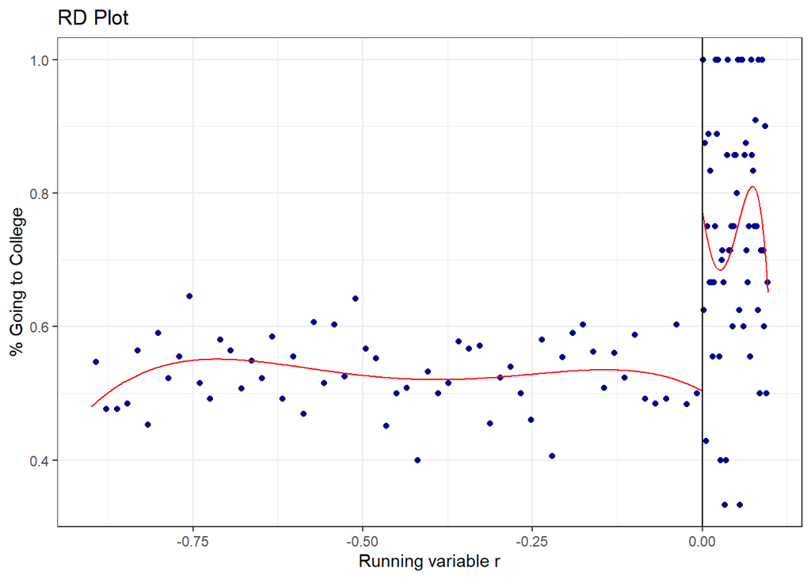

```r
rdplot(texas$college, texas$r, c = 0, x.label = "Running variable r",
       y.label = "% Going to College")
```

- 5 points: Uses rdplot() to create the plot, uses `r` as the running variable and `college` as the outcome.
- 4 points: Uses rdplot() and the right outcome, but uses `ranking` instead of `r`
- 1 points: Attempts a plot with rdplot(), but doesn’t use the correct outcome.
- 0 points: Any other case.

**2.5b) Visually inspecting the plot in 2.5a), do you see a discontinuity of attending college at the cutoff?**

Answer:

TRUE

**2.6a) Using the variable you created in 2.4, and using household income as an outcome, use `rdrobust()` to capture the magnitude of the discontinuity of this variable at the cutoff. Include your code here:** (3 points)

Answer:

```r
rd_income <- rdrobust(texas$hh_income, texas$r, c = 0)

summary(rd_income)
```

```
## Sharp RD estimates using local polynomial regression.
##
## Number of Obs.                 4147
## BW type                       mserd
## Kernel                   Triangular
## VCE method                       NN
##
## Number of Obs.                 3744          403
## Eff. Number of Obs.             194          192
## Order est. (p)                    1            1
## Order bias  (q)                   2            2
## BW est. (h)                   0.047        0.047
## BW bias (b)                   0.067        0.067
## rho (h/b)                     0.696        0.696
## Unique Obs.                    3513          385
##
## =============================================================================
##         Method     Coef. Std. Err.         z     P>|z|      [ 95% C.I. ]
## =============================================================================
##   Conventional  1506.276  1903.983     0.791     0.429 [-2225.462 , 5238.015]
##         Robust         -         -     0.897     0.370 [-2470.882 , 6638.496]
## =============================================================================
```

- 3 points: Uses `r` and `hh_income` as the main variables, and `rd_robust()`. Cutoff is also correct.
- 1 point: Attempts something using `rdrobust()`, but overall not correct.
- 0 points: Any other case.

**2.6b) What is the estimated coefficient?** (2 points)

Answer:

1506.28

**2.6c) What is the estimated p-value** (2 points)

Answer:

0.429

**2.6d) Assess the following statement: “If we want to conduct a RDD in this context, we would expect the coefficient in 2.6b) to be small and not statistically significant”** (1 point)

Answer:

TRUE

**2.7a) Using future earnings as an outcome, write the code you would use for conducting a RDD in this case using a linear model** (4 points)

Answer:

```r
rd_lm_earn <- lm(earnings ~ r*treat, data = texas)

summary(rd_lm_earn)
```

```
##
## Call:
## lm(formula = earnings ~ r * treat, data = texas)
##
## Residuals:
##    Min     1Q Median     3Q    Max
## -32488  -5624    -33   5790  28497
##
## Coefficients:
##             Estimate Std. Error t value Pr(>|t|)
## (Intercept)  62824.0      279.5 224.813  < 2e-16 ***
## r            34964.2      536.5  65.172  < 2e-16 ***
## treat        15867.6      902.4  17.583  < 2e-16 ***
## r:treat     -48081.3    15210.6  -3.161  0.00158 **
## ---
## Signif. codes:  0 '***' 0.001 '**' 0.01 '*' 0.05 '.' 0.1 ' ' 1
##
## Residual standard error: 8555 on 4143 degrees of freedom
## Multiple R-squared:  0.6853, Adjusted R-squared:  0.6851
## F-statistic:  3008 on 3 and 4143 DF,  p-value: < 2.2e-16
```

- 4 points: Creates correct linear model, using the interaction of r and treat on earnings. Doesn’t include redundant terms.
- 3 points: Overall correct, but includes redundant terms using r + treat + treat*r.
- 1 point: Doesn’t fit a linear model (e.g. uses `rdrobust`), but variables are correct.
- 0 points: Any other case

**2.7b) What is the coefficient of interest in 2.7a)** (2 points)

**2.7c) Interpret the previous coefficient** *(Hint: Remember to identify the treatment as in 2.3)* (6 points)

Answer:

On average, for students that have exactly a 10% ranking within their high school, being awarded automatic admission to college via the ranking policy increases their future earnings by $15,867 compared to not being awarded automatic admission.

**2.8a) Finally, let’s conduct the same analysis that we did in 2.7, but using `rdrobust()` in this case. Write your code here:** (4 points)

Answer:

```r
rd_earn <- rdrobust(texas$earnings, texas$r, c = 0)

summary(rd_earn)
```

```
## Sharp RD estimates using local polynomial regression.
##
## Number of Obs.                 4147
## BW type                       mserd
## Kernel                   Triangular
## VCE method                       NN
##
## Number of Obs.                 3744          403
## Eff. Number of Obs.             177          173
## Order est. (p)                    1            1
## Order bias  (q)                   2            2
## BW est. (h)                   0.042        0.042
## BW bias (b)                   0.061        0.061
## rho (h/b)                     0.694        0.694
## Unique Obs.                    3513          385
##
## =============================================================================
##         Method     Coef. Std. Err.         z     P>|z|      [ 95% C.I. ]
## =============================================================================
##   Conventional 17781.823  1871.847     9.500     0.000 [14113.070 , 21450.575]
##         Robust         -         -     8.267     0.000 [14235.572 , 23083.745]
## =============================================================================
```

- 4 points: Uses r and eaarnings as the main variables, and `rd_robust()`. Cutoff is also correct.
- 1 point: Attempts something using `rdrobust()`, but overall not correct.
- 0 points: Any other case.

**2.8b) Thinking about the sign of your coefficient, significance, and magnitude, do your conclusions drastically change between 2.7 and 2.8?** (1 point)

Answer:

FALSE

# Task 3 - Let’s Airbnb

In this task, we will be looking at data from Airbnb to analyze how we can better predict price for a rental. In particular, we are interested in finding what the best price for our unit would be based on what’s out there in the market.

```r
airbnb <- read.csv("https://raw.githubusercontent.com/maibennett/sta235/main/exampleSite/content/Assignments/Homework/HW5/data/airbnb.csv")
```

These are some of the variables we are interested in:

- `room_id`: ID for the property
- `host_id`: ID for the host
- `room_type`: What type of room/unit is rented
- `reviews`: Number of reviews for the place
- `overall_satisfaction`: Rating for the property (from 1-5)
- `accommodates`: How many people it accommodates
- `bedrooms`: Number of bedrooms
- `bathrooms`: Number of bathrooms
- `price`: Price (per night)
- `currency`: Currency of the price
- `rate_type`: Rate type for the unit

For the purpose of all these analyses, only focus on the list of variables given in this description.

**3.1) Let’s start by cleaning our data. Drop variables that we will not use as predictors: `address`, `last_modified`, `latitude`, `longitude`, `location`, and `name`. Additionally, find other variables that do not vary in the dataset (i.e. have the same value for all observations), and drop them as well. Finally, drop all observations which have a missing review or overall satisfaction. How many observations do you have left? How many variables?**

*(Use the same dataset provided, `airbnb`, and don’t create a new one)* (2 points)

Answer:

```r
library(vtable)

sumtable(airbnb)
```

Summary Statistics

| Variable | N | Mean | Std. Dev. | Min | Pctl. 25 | Pctl. 75 | Max |
| --- | --- | --- | --- | --- | --- | --- | --- |
| room_id | 7574 | 17793957.521 | 8736177.416 | 2318 | 11215349 | 24844859.5 | 30998418 |
| host_id | 7574 | 52464162.57 | 59554574.57 | 2536 | 8358454.75 | 80739602 | 231435350 |
| room_type | 7574 |  |  |  |  |  |  |
| … Entire home/apt | 5603 | 74% |  |  |  |  |  |
| … Private room | 1842 | 24.3% |  |  |  |  |  |
| … Shared room | 129 | 1.7% |  |  |  |  |  |
| reviews | 7574 | 47.612 | 65.806 | 0 | 4 | 64 | 687 |
| overall_satisfaction | 6101 | 4.841 | 0.282 | 2.5 | 4.5 | 5 | 5 |
| accommodates | 7574 | 3.683 | 2.332 | 1 | 2 | 4 | 28 |
| bedrooms | 7574 | 1.386 | 1.01 | 0 | 1 | 2 | 8 |
| bathrooms | 7574 | 1.307 | 0.641 | 0 | 1 | 1.5 | 8 |
| price | 7574 | 113.038 | 122.495 | 15 | 65 | 125 | 5900 |
| latitude | 7574 | 47.624 | 0.046 | 47.508 | 47.604 | 47.66 | 47.723 |
| longitude | 7574 | -122.318 | 0.058 | -122.421 | -122.351 | -122.304 | -122.115 |
| currency | 7574 |  |  |  |  |  |  |
| … USD | 7574 | 100% |  |  |  |  |  |
| rate_type | 7574 |  |  |  |  |  |  |
| … nightly | 7574 | 100% |  |  |  |  |  |

```r
airbnb <- airbnb %>% select(-c(address, last_modified, latitude,
                               longitude, location, name, currency, rate_type)) %>%
  filter(!is.na(reviews) & !is.na(overall_satisfaction))

nrow(airbnb)
```

```
## [1] 6101
```

```r
ncol(airbnb)
```

```
## [1] 9
```

We have 6101 observations and 9 variables.

**3.2a) Let’s create a training and a testing dataset! Use 70% of your data for the training dataset, and 30% for the testing dataset. Include all the code you use to create these datasets here.** (5 points)

Answer:

```r
set.seed(123)

n <- nrow(airbnb)

id_train <- sample(1:n, n*0.7)

airbnb.train <- airbnb %>% slice(id_train)
airbnb.test <- airbnb %>% slice(-id_train)
```

- 5 points: (i) sets a seed, (ii) creates a random sample of 70% for the training dataset, and (iii) uses the rest 30% as the testing dataset.
- 2 points: One of the previous items is not correct.
- 0 points: Any other case.

**3.2b) How many observations do you have in your training dataset?** (1 point)

Answer:

4270 observations

**3.2c) What is the average number of reviews in the testing dataset?** (2 points)

Answer:

58

**3.3a) You believe that the number of people the property accommodates is the most predictive variable for price, while one of your colleagues argues is the most popular listings, measured as number of reviews and overall rating. Fit your model and your colleague’s model, in a way that it allows you to compare their performance using the created datasets. Show your code here:** (4 points)

*Note: Use only the information provided here to build your models*

Answer:

```r
lm_you <- lm(price ~ accommodates, data = airbnb.train)

lm_colleague <- lm(price ~ reviews + overall_satisfaction, data = airbnb.train)

rmse(lm_you, airbnb.test)
```

```
## [1] 71.97115
```

```r
rmse(lm_colleague, airbnb.test)
```

```
## [1] 87.55716
```

- 4 points: (i) Fits the correct models, (ii) uses the training dataset for fitting the models, and (iii) uses the testing dataset to assess performance.
- 2 points: One of the previous items is not correct.
- 0 points: Any other case.

**3.3b) What is the RMSE for your model?** *Round your answer to the nearest decimal place* (2 points)

Answer:

72

**3.3c) What is the RMSE for your colleague’s model?** *Round your answer to the nearest decimal place* (2 points)

Answer:

87.6

**3.3d) Which of the two models would you prefer?** (1 point)

Answer:

Your model

**3.4a) Now, fit a prediction model using all the covariates you have in your dataset. Show your code:** (*Note: ID variables are not considered predictors*). (2 points)

Answer:

```r
lm_all <- lm(price ~ . - room_id - host_id, data = airbnb.train)

rmse(lm_all, airbnb.test)
```

```
## [1] 65.35294
```

- 2 points: Fits the correct model in the training dataset.
- 1 point: Fits the correct model but not on the correct dataset.
- 0 points: Any other case.

**3.4b) What is the relevant RMSE in this case?** (2 points)

Answer:

65.4

**3.4c) From the 3 models you have fitted, which one do you prefer?** (2 point)

1. Your model
2. Your colleague’s model
3. This last model

Answer:

C

**3.5a) Finally, run the same model as before, but this time use a cross-validation approach. Use 10-fold CV in this case. Show your code here:** (5 points)

```r
library(caret)

set.seed(123)

train.control <- trainControl(method = "cv", number = 10)

lm_airbnb_cv <- train(price ~ . - room_id - host_id, data = airbnb, method="lm",
               trControl = train.control)
```

- 5 points: (i) Fits the correct model (right variables, right method), (ii) uses a cross-validation approach with 10 folds, (iii) sets a seed, and (iv) fits it in the entire dataset.
- 4 points: Overall correct, but fits the model in the training dataset.
- 2 points: Either (i), (ii) or (iii) are not correct.
- 0 points: Any other case.

**3.5b) What is the relevant RMSE for the model in 3.5a)?** (3 points)

Answer:

| RMSE |
| --- |
| 61 |

(Note that this is the cross-validation RMSE. If you are running your model with the entire sample)

**3.5c) Between the results obtained in 3.4b) and 3.5b), which one would you trust more and why? Be specific.** (5 points)

Answer:

Cross-validation would give us a better measure of the RMSE because it’s less prone to the influence of particular observations, such as outliers, which could be the case when just using one training dataset.

- 5 points: Mentions that cross-validation uses the entire dataset for testing and training, and it is specific that this makes it more robust (e.g. less prone to outliers or specific splits)
- 4 points: Mentions that cross-validation uses the entire dataset for testing and training, but it is not specific why this is a good thing.
- 2 points: Exclusively says that 3.5b) yields a smaller RMSE, and that’s why it is prefered over 3.4b)
- 0 points: Any other case.

**3.6a) Using your best model, out of the 4 that you tested, how much would you charge for an entire apartment, with 2 reviews and an average 5-star rating, that accommodates 2 people, with one bedroom and one bathroom?** *(Hint: You might find the function predict() useful. You can search for ?predict.lm())* (5 points)

Answer:

```r
new_apt <- data.frame(room_type = "Entire home/apt",
                      reviews = 2,
                      overall_satisfaction = 5,
                      accommodates = 2,
                      bedrooms = 1,
                      bathrooms = 1,
                      room_id = 0,
                      host_id = 0)

predict(lm_airbnb_cv, new_apt)
```

```
##        1
## 105.4522
```

105

- Code check for this answer

**3.6b) Would the price of the property in 3.6a) change if you added a sofa-bed that can accommodate one additional person? What would the new price be?** *(Round your answer to nearest integer)* (3 points)

Answer:

```r
new_apt2 <- data.frame(room_type = "Entire home/apt",
                      reviews = 2,
                      overall_satisfaction = 5,
                      accommodates = 3,
                      bedrooms = 1,
                      bathrooms = 1,
                      room_id = 0,
                      host_id = 0)

predict(lm_airbnb_cv, new_apt2)
```

```
##        1
## 106.9715
```

107